# RRBS - Array Comparison for J20 Pathology

Emma Walker

29/06/2021

## Introduction

Many of the entorhinal cortex samples were ran on both the methylation array and using RRBS technology so can be compared. NB these MAY NOT BE identical samples however.

This script looks at the overlap between sites on the two technologies for the regression results for the J20 ECX Pathology models.

Note that these results are PRE FILTERING.

There are 24 signifcant results for the regressions on the array data

There are 3493 signifcant results for the regressions on the RRBS data

## Significant locations that have an identical location in the other technology

# Sites that are significant in both technologies

There are 2300 sites which are in both technologies and 0 sites which are significant using both technologies.

# Sites that are significant in the array data

There are 3 sites which are significant for the array data and have corresponding locations for the RRBS data. 0 of the corresponding sites in the array data are significant using bonferonni correction or using FDR adjustment.

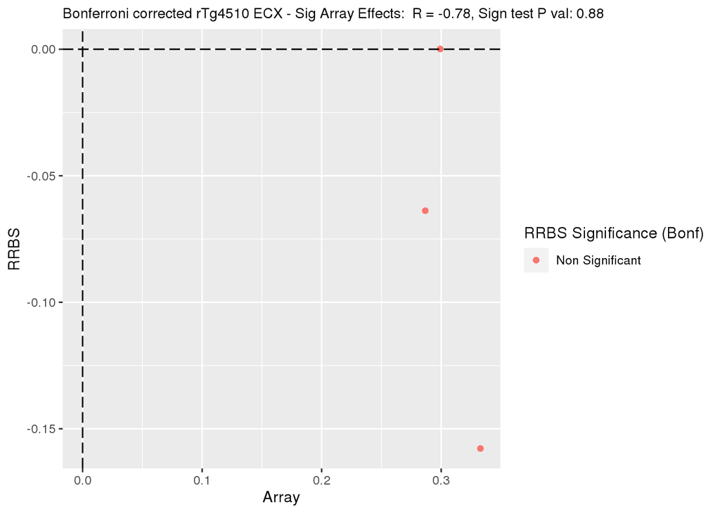

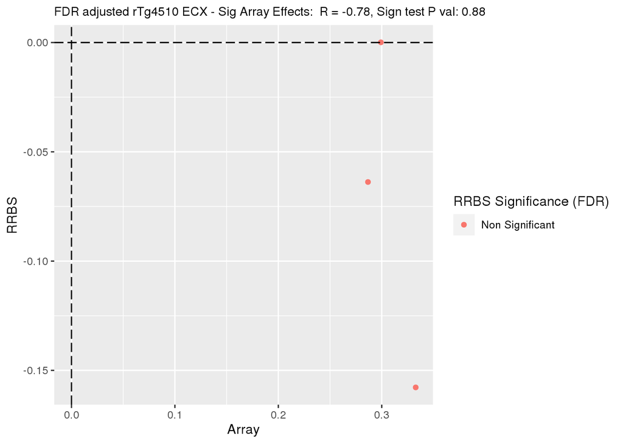

# Sites that are significant in the RRBS data

There are 5 sites which are significant for the RRBS data and have corresponding locations for the array data. 0 of the corresponding sites in the array data are significant using bonferonni correction or using FDR adjustment.

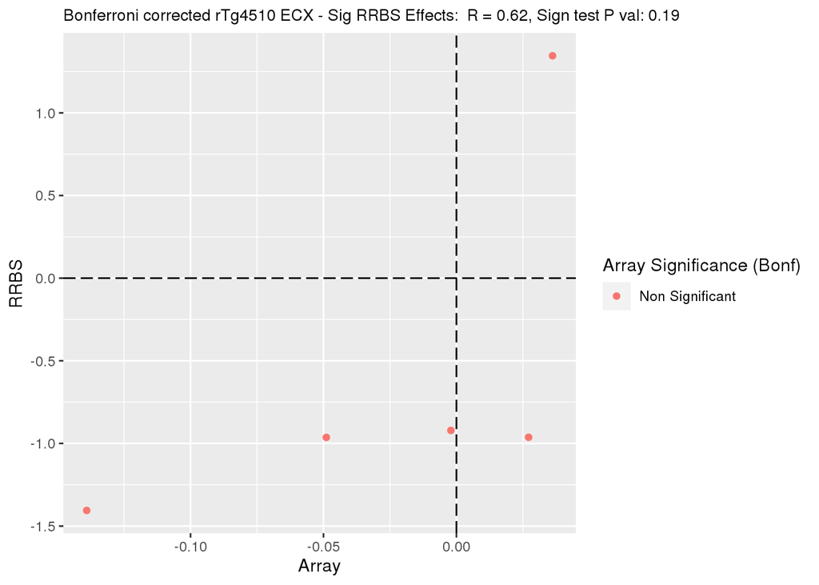

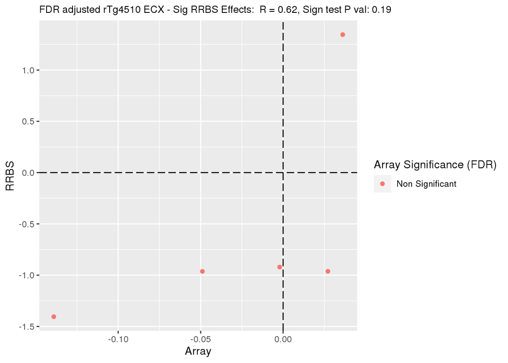

## Significant array sites and RRBS sites +/-100bp

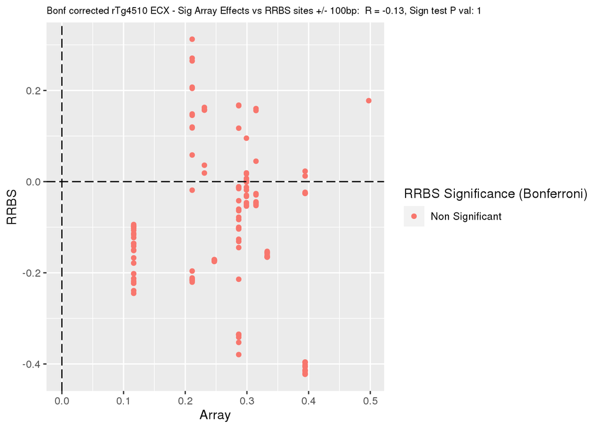

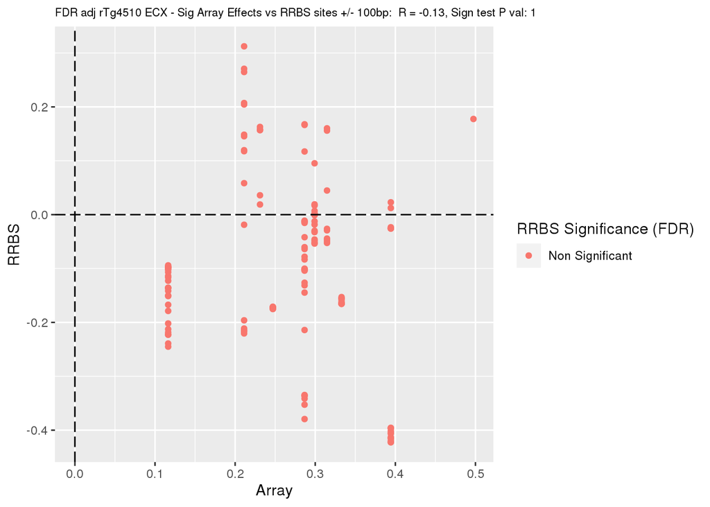

There are 10 significant DMPSs on the array which have a RRBS postion within +/-100bp (137 unique RRBS locations) totalling 137 site pairs.

## Significant RRBS sites and array sites +/-100bp

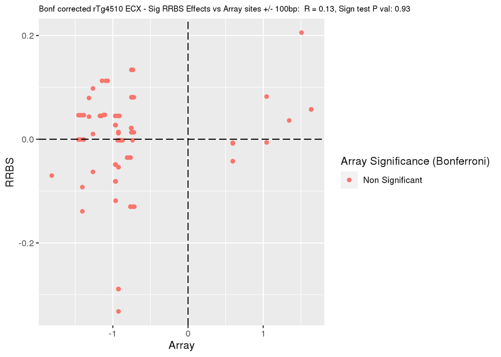

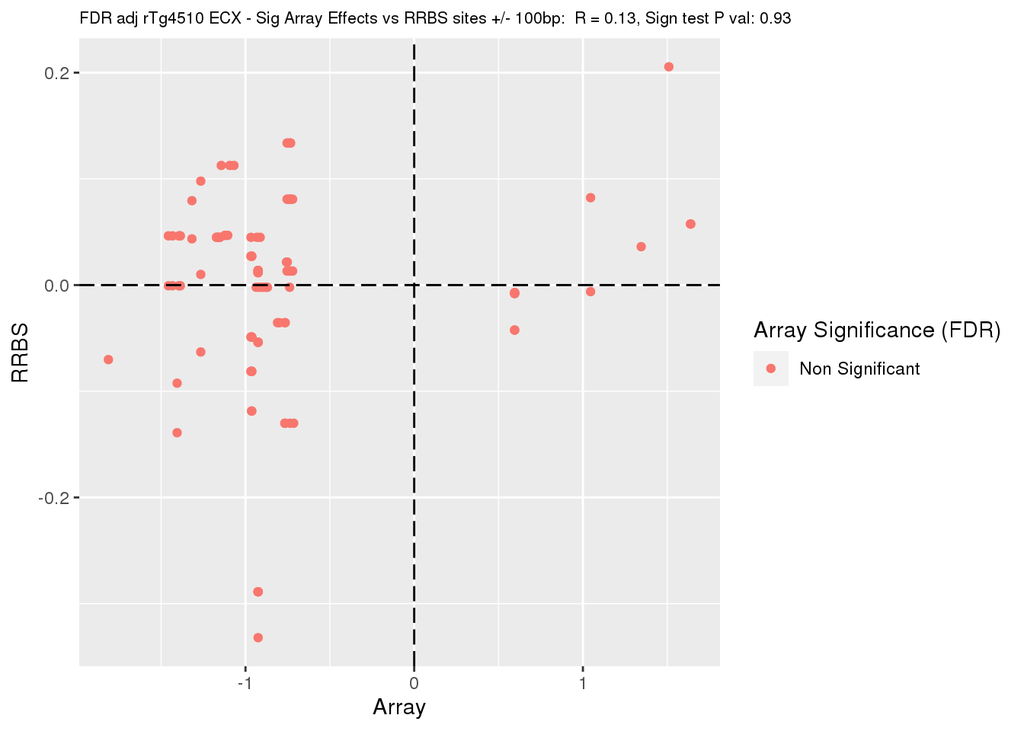

There are 61 significant DMPSs from the RRBS data which have an Array postion within +/-100bp (36 unique array locations) totalling 106 site pairs.

## Significant array sites that are within a significant RRBS DMR

6 of the significant sites for pathology for the array data are within a pathology DMR (n=1313)

## Gene level overlaps between the two technologies

There are 0 unique genes which contain at least one significant site/cpg from both the RRBS and array data.